# A head-to-head comparison of the incremental validity of four major mentalizing tests: A preregistered study in adults

2024-12-11

# S1 Measure Selection

- The RMET was selected for this study due to its status as the most widely used test for the assessment of mentalizing, as evidenced by the 8,185 citations on Google Scholar.
- The Frith-Happé Animations was chosen due to its status as one of the most prevalent mentalizing assessment tools in the context of Autism Spectrum Disorder (989 citations on Google Scholar). Additionally, it exhibits robust psychometric properties, particularly in terms of known-group validity (Livingston et al., 2021; White et al., 2011).
- The Hinting Task and the Faux-pas Test are two widely used instruments, and both satisfy the two criteria established by Quesque et al. (2024) for a test to be deemed capable of assessing mentalizing. In this classification, ideal tests of mentalizing should be able to distinguish between mentalising and lower-level processes and, secondly, require the representation of mental states and the ability to distinguish between one’s own and others’ mental states (mentalising criterion; nonmerging criterion).
- Both Hinting Task and the Faux-pas Test met these criteria, but neither the RMET nor the Frith-Happé animations met the criteria for mentalising and nonmerging as defined by this classification.

# S2 Mentalizing measures

## Hinting Task

### Scoring

Klein et al., 2020

**Hinting Item Scoring:**  
- 2 = Correct answer with first hint  
- 1 = Correct answer with second hint  
- 0 = Paraphrase of what character said or No response  
=> **20 = Total possible points**

### Examples

#### Story 1

George arrives at Angela’s office after a long, hot trip on the motorway. Angela immediately begins to talk about some business ideas. George interrupts Angela to say:

*“Ugh, it has been a long, hot trip on the motorway.”*

• **1st question:** What does George really want to say when he says this?

• **2nd hint:** George continues to say, *“I am thirsty.”*

#### Story 2

Marissa is going to the bathroom to have a shower. Anna just had a bath. When Marissa realises that the bathroom is dirty, she calls Anna and says:

*“Couldn’t you find the cleaner, Anna?”*

• **1st question:** What does Marissa really want to say when she says this?

• **2nd hint:** Marissa continues to say, *“Sometimes you’re very lazy, Anna.”*

#### Story 3

Jacob is going to the supermarket with his mother. They arrive at the sweets section and Jacob says:

*“Look, those sweets look very good.”*

• **1st question:** What does Jacob really want to say when he says this?

• **2nd hint:** Jacob continues to say, *“I’m hungry, mum.”*

## RMET

### Examples

https://osf.io/cnpka/

## Frith-Happé Animations

### Scoring

White et al., 2011

**MCQ-categorization**

Which of these 3 categories best fits the film clip you have just seen?

1. No interaction
2. Physical interaction
3. Mental interaction

**MCQ-feelings** (correct answers in bold)

Coaxing:

1. How do you think the Little Triangle feels at the end of the clip?
   - Proud
   - No feelings
   - **Secure**
   - Annoyed
   - Unsure
2. How do you think the Big Triangle feels at the end of the clip?
   - Frustrated
   - **Loving**
   - Tense
   - Frivolous
   - No feelings

Mocking:

1. How do you think the Little Triangle feels at the end of the clip?
   - No feelings
   - Fulfilled
   - Anxious
   - **Mischievous**
   - Devious
2. How do you think the Big Triangle feels at the end of the clip?
   - **Aggravated**
   - Puzzled
   - Lonely
   - Satisfied
   - No feelings

Seducing:

1. How do you think the Little Triangle feels at the end of the clip?
   - Lost
   - **Cunning**
   - Scared
   - Composed
   - No feelings
2. How do you think the Big Triangle feels at the end of the clip?
   - Excited
   - Eager
   - No feelings
   - Cheerful
   - **Foolish**

Surprising:

1. How do you think the Little Triangle feels at the end of the clip?
   - Provoked
   - No feelings
   - Bored
   - **Pleased**
   - Lucky
2. How do you think the Big Triangle feels at the end of the clip?
   - No feelings
   - Terrified
   - **Delighted**
   - Disappointed
   - Uneasy

### Animations examples

https://osf.io/cnpka/

## Faux-pas Test, Short version

### Example

#### Story 8

https://osf.io/cnpka/

Jeanette bought her friend Anne a crystal bowl for a wedding gift. Anne had a big wedding and there were a lot of presents to keep track of. About a year later, Jeanette was over one night at Anne’s for dinner. Jeanette dropped a wine bottle by accident on the crystal bowl, and the bowl shattered.

*“I’m really sorry, I’ve broken the bowl,”* said Jeanette. *“Don’t worry,”* said Anne, *“I never liked it anyway. Someone gave it to me for my wedding.”*

• **1st question:** Did someone say something they shouldn’t have said? (Tests for detection of faux pas.)

• **2nd question:** Who said something they shouldn’t have said? (Tests for understanding of faux pas.)

• **3rd question:** Why shouldn’t they have said it? (Requires understanding mental state of listener.)

• **4th question:** Why did they say it? (Requires understanding mental state of speaker.)

• **5th question:** Did Anne remember that Jeanette had given her the crystal bowl?

• **6th question:** How do you think Jeanette felt?

• **7th question:** What is Jeanette giving Anne for her wedding?

• **8th question:** How was the bowl broken?

Questions 7 and 8 are control questions to assess the good understanding of the story. Questions 2 to 6 are only asked if the participant answers *“yes”* on the first question.

# S3 Everyday mentalizing abilities

## Interpersonal Reactivity Index

### Perspective-Taking

1. I sometimes find it difficult to see things from the “other guy’s” point of view.
2. I try to look at everybody’s side of a disagreement before I make a decision.
3. I sometimes try to understand my friends better by imagining how things look from their perspective.
4. If I’m sure I’m right about something, I don’t waste much time listening to other people’s arguments.
5. I believe that there are two sides to every question and try to look at them both.
6. When I’m upset at someone, I usually try to “put myself in his shoes” for a while.
7. Before criticizing somebody, I try to imagine how I would feel if I were in their place.

### Empathic Concern

1. I often have tender, concerned feelings for people less fortunate than me.
2. Sometimes I don’t feel very sorry for other people when they are having problems.
3. When I see someone being taken advantage of, I feel kind of protective towards them.
4. Other people’s misfortunes do not usually disturb me a great deal.
5. When I see someone being treated unfairly, I sometimes don’t feel very much pity for them.
6. I am often quite touched by things that I see happen.
7. I would describe myself as a pretty soft-hearted person.

# S4 Loneliness

## UCLA-Loneliness Scale-3

1. First, how often do you feel that you lack companionship ?
2. How often do you feel left out ?
3. How often do you feel isolated from others?

# S5 Planned Analyses

## Commonality model

```r
library(psych)
library(MASS)
library(yhat)
library(boot)

set.seed(12134)
r = runif(64, 0.1, 0.4)
mat = matrix(r, nrow=8)
diag(mat) <- 1
mu=c(19, 17, 34, 16, 38, 6, 9, 11)
dat_1 <- as.data.frame(mvrnorm(n=19, mu=rep(0,8), Sigma=mat))
colnames(dat_1) <- c("RMET", "FauxPas", "Hinting", "Frith", "Iri", "UCLA3", "language", "reasoning")
dat_1$ID = 1:nrow(dat_1)

## Commonality analysis
res_lm = lm(Iri~RMET+FauxPas+Frith+Hinting+language+reasoning, data=dat_1)
res_dom <- calc.yhat(res_lm)
boot.out = boot(data=dat_1, yhat::boot.yhat, 100,
                 lmOut=res_lm, regrout0=res_dom)
boot_results = booteval.yhat(res_dom, boot.out,bty="perc",.95,3)
```

## Main hypothesis

### Test of incremental validity

```r
results_filtered <- boot_results$combCIaps["language,reasoning",
                                          c("RMET.Inc", "FauxPas.Inc", "Frith.Inc", "Hinting.Inc")]

print(results_filtered)
```

```
##                              RMET.Inc        FauxPas.Inc          Frith.Inc
## language,reasoning 0.049(0.000,0.359) 0.266(0.002,0.601) 0.113(0.001,0.403)
##                           Hinting.Inc
## language,reasoning 0.121(0.000,0.445)
```

## Secondary hypothesis

### Comparison of incremental validity

```r
results_filtered <- boot_results$combCIincDiff["language,reasoning",
                                          c("RMET.Inc-FauxPas.Inc", "RMET.Inc-Frith.Inc", "RMET.Inc-Hinting.Inc", "FauxPas.Inc-Frith.Inc", "FauxPas.Inc-Hinting.Inc", "Frith.Inc-Hinting.Inc")]

print(results_filtered)
```

```
##                     RMET.Inc-FauxPas.Inc    RMET.Inc-Frith.Inc
## language,reasoning -0.217(-0.528,0.230)  -0.064(-0.368,0.305)
##                     RMET.Inc-Hinting.Inc FauxPas.Inc-Frith.Inc
## language,reasoning -0.072(-0.365,0.230)   0.153(-0.189,0.432)
##                    FauxPas.Inc-Hinting.Inc Frith.Inc-Hinting.Inc
## language,reasoning    0.145(-0.319,0.518)  -0.008(-0.320,0.308)
```

## Plot

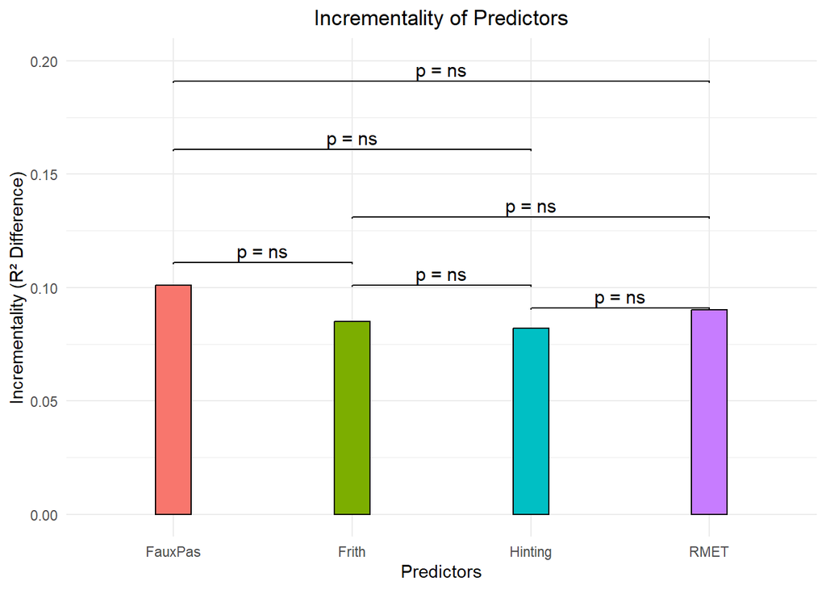

```r
library(ggplot2)
library(ggsignif)
data_plot <- data.frame(
  Test = c("RMET", "Hinting", "Frith", "FauxPas"),
  Incrementality = c(0.090, 0.082, 0.085, 0.101)
)

comparisons <- list(
  c("RMET", "Hinting"),
  c("RMET", "Frith"),
  c("Frith", "Hinting"),
  c("RMET", "FauxPas"),
  c("Frith", "FauxPas"),
  c("Hinting", "FauxPas")
)

annotations <- c("p = ns", "p = ns", "p = ns", "p = ns", "p = ns", "p = ns")

y_positions <- c(0.09,
                 0.13,
                 0.1,
                 0.19,
                 0.11,
                 0.16)

ggplot(data_plot, aes(x = Test, y = Incrementality, fill = Test)) +
  geom_bar(stat = "identity", color = "black", width = 0.2) +
  geom_signif(
    comparisons = comparisons,
    annotations = annotations,
    y_position = y_positions,
    tip_length = 0.03,
    textsize = 4
  ) +
  labs(
    title = "Incrementality of Predictors",
    x = "Predictors",
    y = "Incrementality (R² Difference)"
  ) +
  theme_minimal() +
  theme(
    plot.title = element_text(hjust = 0.5),
    legend.position = "none"
  ) +
  ylim(0, 0.2)
```